# 04_twitter_homework

Steven Cognac

4/20/2022

### Assignment

5. The Twitter data download comes with a variable called “Sentiment” that must be calculated by Brandwatch. Use your own method to assign each tweet a polarity score (Positive, Negative, Neutral) and compare your classification to Brandwatch’s (hint: you’ll need to revisit the “raw_tweets” data frame).

```r
library(quanteda)
#devtools::install_github("quanteda/quanteda.sentiment") #not available currently through CRAN
library(quanteda.sentiment)
library(quanteda.textstats)
library(tidyverse)
library(tidytext)
library(lubridate)
library(wordcloud) #visualization of common words in the data set
library(reshape2)
```

# Read in Twitter data

```r
raw_tweets <- read.csv("https://raw.githubusercontent.com/MaRo406/EDS_231-text-sentiment/main/dat/IPCC_tweets_April1-10_sample.csv", header=TRUE)

dat<- raw_tweets[,c(5,7)] # Extract Date and Title fields

tweets <- tibble(text = dat$Title,
                  id = seq(1:length(dat$Title)),
                 date = as.Date(dat$Date,'%m/%d/%y'))
```

# Part 1. Think about how to further clean a twitter data set. Let’s assume that the mentions of twitter accounts (@) is not useful to us. Remove them from the text field of the tweets tibble.

Here we remove the “@” symbols, or account names, from the tweets.

```r
# let's find the "@" from the tweets
tweets <- tweets %>%
  mutate(contains_account = str_detect(text, "@[a-z,A-Z]*", negate = FALSE))

# let's remove those @ symbols and any word that immediately follows it
tweets$text <- gsub("@[a-z,A-Z]*", "", tweets$text)
tweets$text <- str_to_lower(tweets$text)

# let's double check if we removed all the "@" symbols
tweets <- tweets %>%
  mutate(contains_account = str_detect(text, "@[a-z,A-Z]*", negate = FALSE))
```

# Part 2. Compare the ten most common terms in the tweets per day. Do you notice anything interesting?

To do this we’ll start by tokenizing our tweets. This includes extracting individual words by date from each tweet. While we’re at it let’s remove stop_words, or words that don’t actually carry sentiment or meaning like ‘the’, ‘after’, ‘so’, ‘you’, etc.

```r
#tokenize tweets to individual words
words <- tweets %>%
  select(id, date, text) %>%
  unnest_tokens(output = word, input = text, token = "words")

# removes all the stop_words from the 'words$text' column
words_tokenized <- words %>%
  anti_join(stop_words)
```

Looks like there’s still a fair amount of fluff in our word bank. Let’s remove additonal phrases and fluff words manually

```r
# remove unwanted words
clean_tokens <- str_remove_all(words_tokenized$word, "t.co")
clean_tokens <- str_remove_all(clean_tokens, "here's")
clean_tokens <- str_remove_all(clean_tokens, "https")
clean_tokens <- str_remove_all(clean_tokens, "\\.")

#remove all numbers
clean_tokens <- str_remove_all(clean_tokens, "[:digit:]")

# removes "'s", "."
clean_tokens <- gsub("’s", '', clean_tokens)

# add cleaned words to stop_words
words_tokenized$clean <- clean_tokens

#remove the empty strings
tib <-subset(words_tokenized, clean!="")

#reassign
words_tokenized <- tib
```

Now that things are cleaned up, let’s plot our top Twitter words for the period April 1-10, 2022.

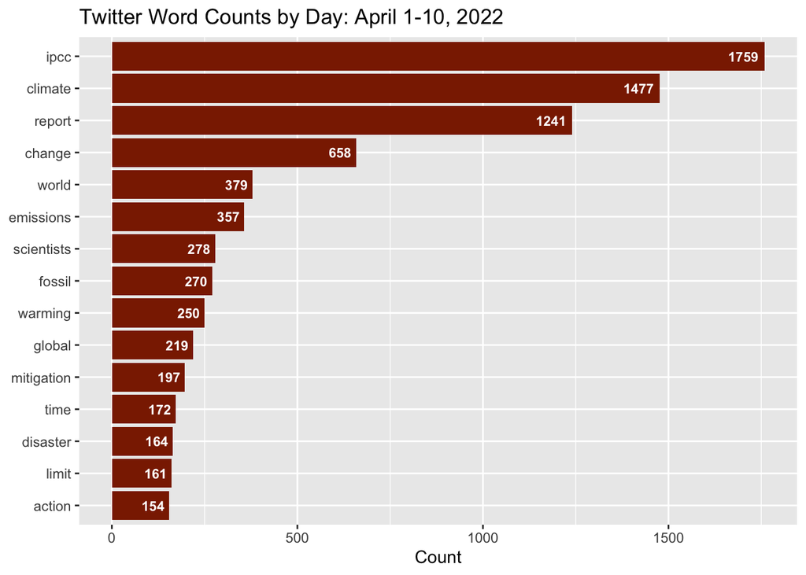

```r
#plot the updated word frequency plot
tweet_freq_all <- words_tokenized %>%
  count(clean, sort = TRUE) %>%
  filter(n > 150) %>% #illegible with all the words displayed
  mutate(clean = reorder(clean, n)) %>%
  ggplot(aes(n, clean)) +
  geom_col(fill = "orangered4") +
  geom_text(aes(label = n), hjust = 1.2, colour = "white", fontface = "bold", size = 3) +
  labs(title = "Twitter Word Counts by Day: April 1-10, 2022",
       y = NULL,
       x = "Count")
tweet_freq_all
```

## Now let’s plot the top 10 words by day.

First we’ll group our tokenized_words() by date, then count the frequency of each word, and finally grab the top 10 words from each date. (Notice how some days have more than 10 words. If we take a look we can see there are some words that show up the same number of times.)

```r
#plot the updated word frequency plot
tweet_freq <- words_tokenized %>%
  group_by(date) %>%
  count(word, sort = TRUE) %>%
  mutate(word = reorder(word, n)) %>%
  arrange(date, -n) %>%
  top_n(n=10, wt = n) %>%
  ungroup()
```

We’ll use facet_wrap() to group our top 10 words by day. But before we do that, we’ll need to reorder our columns to decending order. Julie Silge has a great blog [tutorial](https://juliasilge.com/blog/reorder-within/) on that.

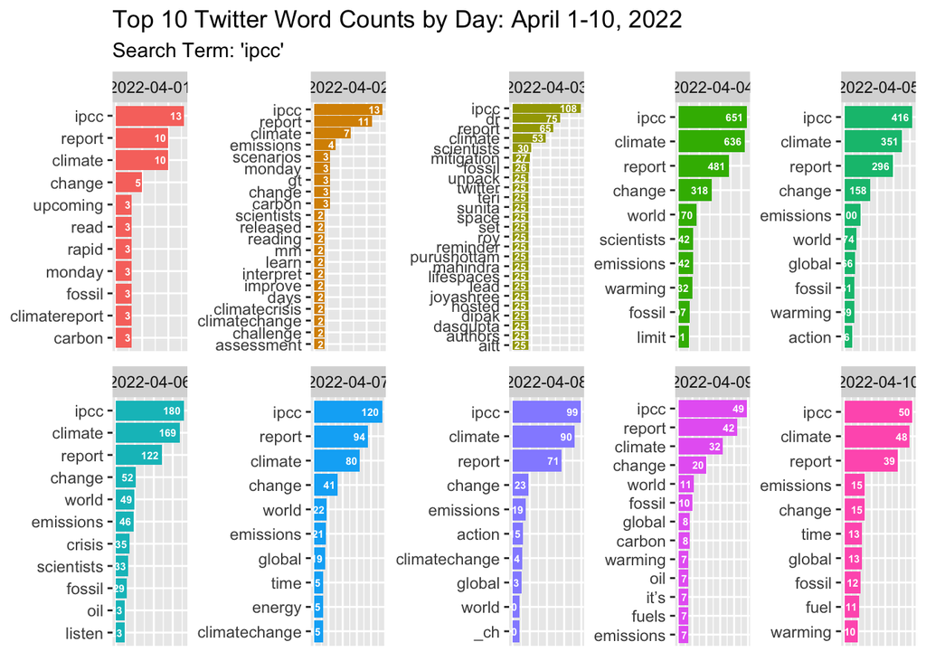

```r
tweet_freq_plot <- tweet_freq %>%
  mutate(name = reorder_within(word, n, date)) %>%

  # plot setup
  ggplot(aes(n, name, fill = as.factor(date))) +
  geom_col() +
  geom_text(aes(label = n), hjust = 1.2, colour = "white", fontface = "bold", size = 2) +
  facet_wrap(~date, scales = "free", ncol = 5) +
  scale_y_reordered() +
  labs(title = "Top 10 Twitter Word Counts by Day: April 1-10, 2022",
       subtitle = "Search Term: 'ipcc'",
       y = NULL) +

  # remove x-axis text
  theme(legend.position="none",
        axis.title.x=element_blank(),
        axis.text.x=element_blank(),
        axis.ticks.x=element_blank())

tweet_freq_plot
```

From this we can see words like ‘ipcc’, ‘report’, ‘climate’, and ‘change’ seem to be our top contenters. We have low counts for all words on April 1 and seems to peak April 4, 2022. This date corresponds with an [IPCC Working Group 3 press conference](https://www.ipcc.ch/2022/04/03/new-time-ipcc-wgiii-press-conference/).